# 3b_TF-IDF

### Now that TF/IDF model is computed, save it as df

```python
# Name the new columns for feature vectors
# TFIDF-i are the TF/IDF Doc2Vec dimensions (200)
feat_cols = [ 'TFIDF-'+str(i) for i in range(len(most_Freq_Words)) ]
```

```python
# Create an empty df for TF-IDF vectors (same size as the number of docs)
feats_df = pd.DataFrame(0, index=range(len(alex_df)), dtype='float', columns=feat_cols)
```

```python
feats_df.shape
```

```
(381, 200)
```

```python
feats_df.sample(4)
```

|  | TFIDF-0 | TFIDF-1 | TFIDF-2 | TFIDF-3 | TFIDF-4 | TFIDF-5 | TFIDF-6 | TFIDF-7 | TFIDF-8 | TFIDF-9 | ... | TFIDF-190 | TFIDF-191 | TFIDF-192 | TFIDF-193 | TFIDF-194 | TFIDF-195 | TFIDF-196 | TFIDF-197 | TFIDF-198 | TFIDF-199 |
| --- | --- | --- | --- | --- | --- | --- | --- | --- | --- | --- | --- | --- | --- | --- | --- | --- | --- | --- | --- | --- | --- |
| 151 | 0.0 | 0.0 | 0.0 | 0.0 | 0.0 | 0.0 | 0.0 | 0.0 | 0.0 | 0.0 | ... | 0.0 | 0.0 | 0.0 | 0.0 | 0.0 | 0.0 | 0.0 | 0.0 | 0.0 | 0.0 |
| 363 | 0.0 | 0.0 | 0.0 | 0.0 | 0.0 | 0.0 | 0.0 | 0.0 | 0.0 | 0.0 | ... | 0.0 | 0.0 | 0.0 | 0.0 | 0.0 | 0.0 | 0.0 | 0.0 | 0.0 | 0.0 |
| 142 | 0.0 | 0.0 | 0.0 | 0.0 | 0.0 | 0.0 | 0.0 | 0.0 | 0.0 | 0.0 | ... | 0.0 | 0.0 | 0.0 | 0.0 | 0.0 | 0.0 | 0.0 | 0.0 | 0.0 | 0.0 |
| 367 | 0.0 | 0.0 | 0.0 | 0.0 | 0.0 | 0.0 | 0.0 | 0.0 | 0.0 | 0.0 | ... | 0.0 | 0.0 | 0.0 | 0.0 | 0.0 | 0.0 | 0.0 | 0.0 | 0.0 | 0.0 |

4 rows × 200 columns

```python
# Fill the features df from TF-IDF model matrix
for i in range(len(alex_df)):  # For each document token list
    for j in range(len(most_Freq_Words)):  # For each token in most frequent tokens
        feats_df['TFIDF-'+str(j)].iloc[i] = TF_IDF_model[i][j]
```

```python
feats_df.describe()
```

|  | TFIDF-0 | TFIDF-1 | TFIDF-2 | TFIDF-3 | TFIDF-4 | TFIDF-5 | TFIDF-6 | TFIDF-7 | TFIDF-8 | TFIDF-9 | ... | TFIDF-190 | TFIDF-191 | TFIDF-192 | TFIDF-193 | TFIDF-194 | TFIDF-195 | TFIDF-196 | TFIDF-197 | TFIDF-198 | TFIDF-199 |
| --- | --- | --- | --- | --- | --- | --- | --- | --- | --- | --- | --- | --- | --- | --- | --- | --- | --- | --- | --- | --- | --- |
| count | 381.000000 | 381.000000 | 381.000000 | 381.000000 | 381.000000 | 381.000000 | 381.000000 | 381.000000 | 381.000000 | 381.000000 | ... | 381.000000 | 381.000000 | 381.000000 | 381.000000 | 381.000000 | 381.00000 | 381.000000 | 381.000000 | 381.000000 | 381.000000 |
| mean | 0.029986 | 0.024811 | 0.031825 | 0.017432 | 0.020714 | 0.025600 | 0.014106 | 0.011445 | 0.013892 | 0.010146 | ... | 0.003512 | 0.002881 | 0.003889 | 0.004005 | 0.004117 | 0.00158 | 0.004250 | 0.003093 | 0.004928 | 0.004489 |
| std | 0.073887 | 0.070279 | 0.102830 | 0.052363 | 0.070906 | 0.085243 | 0.070297 | 0.048908 | 0.062182 | 0.040440 | ... | 0.036138 | 0.029102 | 0.041783 | 0.036481 | 0.042108 | 0.01878 | 0.051032 | 0.026493 | 0.055577 | 0.039896 |
| min | 0.000000 | 0.000000 | 0.000000 | 0.000000 | 0.000000 | 0.000000 | 0.000000 | 0.000000 | 0.000000 | 0.000000 | ... | 0.000000 | 0.000000 | 0.000000 | 0.000000 | 0.000000 | 0.00000 | 0.000000 | 0.000000 | 0.000000 | 0.000000 |
| 25% | 0.000000 | 0.000000 | 0.000000 | 0.000000 | 0.000000 | 0.000000 | 0.000000 | 0.000000 | 0.000000 | 0.000000 | ... | 0.000000 | 0.000000 | 0.000000 | 0.000000 | 0.000000 | 0.00000 | 0.000000 | 0.000000 | 0.000000 | 0.000000 |
| 50% | 0.000000 | 0.000000 | 0.000000 | 0.000000 | 0.000000 | 0.000000 | 0.000000 | 0.000000 | 0.000000 | 0.000000 | ... | 0.000000 | 0.000000 | 0.000000 | 0.000000 | 0.000000 | 0.00000 | 0.000000 | 0.000000 | 0.000000 | 0.000000 |
| 75% | 0.000000 | 0.000000 | 0.000000 | 0.000000 | 0.000000 | 0.000000 | 0.000000 | 0.000000 | 0.000000 | 0.000000 | ... | 0.000000 | 0.000000 | 0.000000 | 0.000000 | 0.000000 | 0.00000 | 0.000000 | 0.000000 | 0.000000 | 0.000000 |
| max | 0.541770 | 0.616152 | 0.958724 | 0.402195 | 0.441026 | 0.623314 | 0.882321 | 0.441160 | 0.522119 | 0.367929 | ... | 0.593006 | 0.461227 | 0.691840 | 0.499611 | 0.666148 | 0.26803 | 0.922453 | 0.333074 | 0.999222 | 0.570984 |

8 rows × 200 columns

```python
# Add the label and other vbles to the df as a new column
feats_df['Alex_A'] = alex_df['Alex_A'].get_values()
feats_df['Code'] = alex_df['Code'].get_values()
feats_df['F1'] = alex_df['F1'].get_values()
feats_df['F2'] = alex_df['F2'].get_values()
feats_df['F3'] = alex_df['F3'].get_values()
feats_df['Card'] = alex_df['Card'].get_values()
```

```python
feats_df.sample(4)
```

|  | TFIDF-0 | TFIDF-1 | TFIDF-2 | TFIDF-3 | TFIDF-4 | TFIDF-5 | TFIDF-6 | TFIDF-7 | TFIDF-8 | TFIDF-9 | ... | TFIDF-196 | TFIDF-197 | TFIDF-198 | TFIDF-199 | Alex_A | Code | F1 | F2 | F3 | Card |
| --- | --- | --- | --- | --- | --- | --- | --- | --- | --- | --- | --- | --- | --- | --- | --- | --- | --- | --- | --- | --- | --- |
| 7 | 0.0 | 0.0 | 0.0 | 0.0 | 0.0 | 0.0 | 0.0 | 0.0 | 0.000000 | 0.000000 | ... | 0.0 | 0.000000 | 0.0 | 0.0 | 0 | 107b920c3318629af25cd9fe09c2bd25 | 14 | 10 | 13 | 11 |
| 220 | 0.0 | 0.0 | 0.0 | 0.0 | 0.0 | 0.0 | 0.0 | 0.0 | 0.290066 | 0.000000 | ... | 0.0 | 0.000000 | 0.0 | 0.0 | 0 | 116457052e0ddfbabafad6f14feb1ab | 21 | 16 | 20 | 9VH |
| 109 | 0.0 | 0.0 | 0.0 | 0.0 | 0.0 | 0.0 | 0.0 | 0.0 | 0.000000 | 0.000000 | ... | 0.0 | 0.000000 | 0.0 | 0.0 | 0 | 65e24a82d12f4a91135102a8a7eaab06 | 17 | 9 | 13 | 11 |
| 89 | 0.0 | 0.0 | 0.0 | 0.0 | 0.0 | 0.0 | 0.0 | 0.0 | 0.047465 | 0.046827 | ... | 0.0 | 0.072671 | 0.0 | 0.0 | 0 | 35ec883bd1624fd39bb891159f49d60d | 8 | 6 | 19 | 9VH |

4 rows × 206 columns

### Persist the TF/IDF model

```python
# Save TF/IDF Model
TFIDF_Models_path = "D:\\Dropbox-Array2001\\Dropbox\\DataSets\\Prolexitim-Dataset\\Prolexitim_v2_TFIDF.csv"
feats_df.to_csv(TFIDF_Models_path, sep=';', encoding='utf-8', index=False)
```

# Reduce TF/IDF vector dimensionality

[More info about PCA](https://en.wikipedia.org/wiki/Principal_component_analysis)

[More info about t-SNE](https://en.wikipedia.org/wiki/T-distributed_stochastic_neighbor_embedding)

```python
from sklearn.decomposition import PCA
from sklearn.manifold import TSNE
```

### Let's go first with PCA:

```python
pca = PCA(n_components=3)
pca_result = pca.fit_transform(feats_df[feat_cols].values)

feats_df['pca-1'] = pca_result[:,0]
feats_df['pca-2'] = pca_result[:,1]
feats_df['pca-3'] = pca_result[:,2]
```

```python
print('Explained variation per principal component: {}'.format(pca.explained_variance_ratio_))
```

```
Explained variation per principal component: [0.04508953 0.0373872  0.03130043]
```

```python
feats_df.sample(4)
```

|  | TFIDF-0 | TFIDF-1 | TFIDF-2 | TFIDF-3 | TFIDF-4 | TFIDF-5 | TFIDF-6 | TFIDF-7 | TFIDF-8 | TFIDF-9 | ... | TFIDF-199 | Alex_A | Code | F1 | F2 | F3 | Card | pca-1 | pca-2 | pca-3 |
| --- | --- | --- | --- | --- | --- | --- | --- | --- | --- | --- | --- | --- | --- | --- | --- | --- | --- | --- | --- | --- | --- |
| 263 | 0.0 | 0.0 | 0.0 | 0.0 | 0.0 | 0.0000 | 0.0 | 0.0 | 0.074588 | 0.0 | ... | 0.0 | 0 | af67553b2ca884d23497afdf7a2b10d8 | 14 | 10 | 12 | 11 | -0.014983 | -0.080374 | 0.069052 |
| 117 | 0.0 | 0.0 | 0.0 | 0.0 | 0.0 | 0.2424 | 0.0 | 0.0 | 0.000000 | 0.0 | ... | 0.0 | 0 | efb2088a8ab28dc16c158813ae396ec8 | 13 | 9 | 13 | 10 | 0.096805 | -0.005766 | -0.018635 |
| 28 | 0.0 | 0.0 | 0.0 | 0.0 | 0.0 | 0.0000 | 0.0 | 0.0 | 0.000000 | 0.0 | ... | 0.0 | 0 | 0869cf46fd51daaf1ee9ad0a2d2dba6a | 14 | 10 | 16 | 7VH | -0.034305 | -0.033321 | -0.038904 |
| 368 | 0.0 | 0.0 | 0.0 | 0.0 | 0.0 | 0.0000 | 0.0 | 0.0 | 0.000000 | 0.0 | ... | 0.0 | 1 | 67cd896903cb095bfbfca4f8a62ef19a | 29 | 24 | 25 | 9VH | -0.016316 | -0.045433 | -0.024120 |

4 rows × 209 columns

### Does TF/IDF 3D-projected (PCA) features discriminate alexithymia?

```python
%matplotlib inline
import matplotlib.pyplot as plt
from mpl_toolkits.mplot3d import Axes3D
from matplotlib.lines import Line2D
import seaborn as sns
```

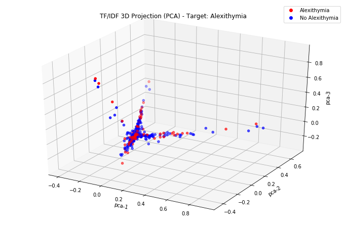

```python
colors = {1:'red', 0:'blue'}
ax = plt.figure(figsize=(12,8)).gca(projection='3d')
scatter = ax.scatter(
    xs=feats_df["pca-1"],
    ys=feats_df["pca-2"],
    zs=feats_df["pca-3"],
    c=feats_df['Alex_A'].apply(lambda x: colors[x])
)
ax.set_xlabel('pca-1')
ax.set_ylabel('pca-2')
ax.set_zlabel('pca-3')
legend_elements = [Line2D([0], [0], marker='o', color='w', label='Alex', markerfacecolor='r', markersize=8),
                   Line2D([0], [0], marker='o', color='w', label='NoAlex', markerfacecolor='b', markersize=8)]
ax.legend(legend_elements, ['Alexithymia','No Alexithymia'])
plt.title("TF/IDF 3D Projection (PCA) - Target: Alexithymia")
plt.show()
```

- Looks like TF/IDF vector space model (PCA-projected) is not a good candidate to classify alexithymia

### Does TF/IDF 3D-projected (PCA) features discriminate cards?

```python
feats_df.Card.value_counts()
```

```
9VH     89
1       85
11      83
13HM    81
12VN     8
3VH      6
7VH      6
13N      5
13V      5
10       4
18NM     3
13VH     2
15HM     1
!·HM     1
9BM      1
10N      1
Name: Card, dtype: int64
```

```python
# drop under-represented cards
cards_df = feats_df.drop(feats_df[(feats_df.Card != '9VH') & (feats_df.Card != '1') & (feats_df.Card != '11') & (feats_df.Card != '13HM')].index)
```

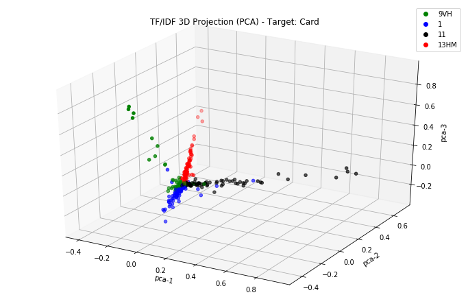

```python
colors = {'9VH': 'blue', '1': 'red', '11': 'green', '13HM': 'black'}
ax = plt.figure(figsize=(12,8)).gca(projection='3d')
ax.scatter(
    xs=cards_df["pca-1"],
    ys=cards_df["pca-2"],
    zs=cards_df["pca-3"],
    c=cards_df['Card'].apply(lambda x: colors[x])
)
ax.set_xlabel('pca-1')
ax.set_ylabel('pca-2')
ax.set_zlabel('pca-3')

legend_elements = [Line2D([0], [0], marker='o', color='w', label='9VH', markerfacecolor='green', markersize=8),
                   Line2D([0], [0], marker='o', color='w', label='1', markerfacecolor='blue', markersize=8),
                   Line2D([0], [0], marker='o', color='w', label='11', markerfacecolor='black', markersize=8),
                   Line2D([0], [0], marker='o', color='w', label='13HM', markerfacecolor='red', markersize=8)]
ax.legend(legend_elements, ['9VH','1','11','13HM'])

plt.title("TF/IDF 3D Projection (PCA) - Target: Card")
plt.show()
```

- Looks like TF/IDF vector space model (PCA-projected) is a good candidate to classify Cards

```python
# Add TF/IDF Vectors PCA components as interesting features
alex_df['TFIDF_PCA_1'] = feats_df["pca-1"]
alex_df['TFIDF_PCA_2'] = feats_df["pca-2"]
alex_df['TFIDF_PCA_3'] = feats_df["pca-3"]
```

```python
alex_df.sample(4)
```

|  | Code | TAS20 | F1 | F2 | F3 | Gender | Age | Card | T_Metaphors | T_ToM | ... | ADP_Ratio | ADJ_Ratio | TTR | HTR | BoW_PCA_1 | BoW_PCA_2 | BoW_PCA_3 | TFIDF_PCA_1 | TFIDF_PCA_2 | TFIDF_PCA_3 |
| --- | --- | --- | --- | --- | --- | --- | --- | --- | --- | --- | --- | --- | --- | --- | --- | --- | --- | --- | --- | --- | --- |
| 322 | 49017f5627f677325152301bca07441e | 52 | 13 | 16 | 23 | 1 | 37 | 9VH | 0 | 1 | ... | 0.187500 | 0.020833 | 0.229167 | 0.812500 | -0.270385 | -0.341711 | 0.571680 | -0.020994 | -0.048152 | -0.048099 |
| 36 | f73539399a0f386943ee6d98b400367f | 46 | 15 | 14 | 17 | 1 | 53 | 9VH | 0 | 0 | ... | 0.240000 | 0.120000 | 0.320000 | 0.760000 | -0.463384 | -0.678248 | 0.678276 | -0.018851 | -0.092648 | -0.103661 |
| 190 | 5c816bcb2c5a1a6c5c353f7b24bba02f | 48 | 10 | 16 | 22 | 1 | 28 | 13HM | 0 | 1 | ... | 0.125000 | 0.000000 | 0.437500 | 1.000000 | -0.585050 | 0.993939 | 0.132209 | 0.325701 | 0.063401 | 0.003860 |
| 269 | bb1599aefddc592c339f073d564b5d47 | 49 | 22 | 11 | 16 | 2 | 26 | 9VH | 0 | 1 | ... | 0.173913 | 0.173913 | 0.347826 | 0.826087 | -0.344969 | -0.381177 | -0.103984 | -0.021718 | -0.069849 | -0.065884 |

4 rows × 74 columns

```python
# Save Updated features dataset
Feats_3_path = "D:\\Dropbox-Array2001\\Dropbox\\DataSets\\Prolexitim-Dataset\\Prolexitim_v2_features_3.csv"
alex_df.to_csv(Feats_3_path, sep=';', encoding='utf-8', index=False)
```

## Let's see now how t-SNE projection behaves

```python
# Using t-SNE to reduce to 3 dimensions
tsne = TSNE(n_components=3, verbose=0, perplexity=40, n_iter=300)
tsne_results = tsne.fit_transform(feats_df[feat_cols].values)
```

```python
feats_df['tsne-1'] = tsne_results[:,0]
feats_df['tsne-2'] = tsne_results[:,1]
feats_df['tsne-3'] = tsne_results[:,2]
```

```python
feats_df.sample(4)
```

|  | TFIDF-0 | TFIDF-1 | TFIDF-2 | TFIDF-3 | TFIDF-4 | TFIDF-5 | TFIDF-6 | TFIDF-7 | TFIDF-8 | TFIDF-9 | ... | F1 | F2 | F3 | Card | pca-1 | pca-2 | pca-3 | tsne-1 | tsne-2 | tsne-3 |
| --- | --- | --- | --- | --- | --- | --- | --- | --- | --- | --- | --- | --- | --- | --- | --- | --- | --- | --- | --- | --- | --- |
| 277 | 0.000000 | 0.000000 | 0.079894 | 0.0 | 0.000000 | 0.0909 | 0.0 | 0.0 | 0.0 | 0.000000 | ... | 22 | 20 | 27 | 13HM | 0.071671 | -0.002487 | -0.008064 | 29.137648 | -0.340803 | -16.004026 |
| 138 | 0.000000 | 0.000000 | 0.000000 | 0.0 | 0.000000 | 0.2424 | 0.0 | 0.0 | 0.0 | 0.143084 | ... | 20 | 18 | 17 | 18NM | 0.106327 | 0.003799 | -0.011453 | -4.535561 | -28.728769 | 10.423445 |
| 205 | 0.000000 | 0.000000 | 0.000000 | 0.0 | 0.000000 | 0.0000 | 0.0 | 0.0 | 0.0 | 0.000000 | ... | 19 | 19 | 25 | 11 | -0.025296 | -0.056036 | -0.022375 | 7.173934 | 9.021512 | -15.811658 |
| 163 | 0.162531 | 0.184845 | 0.000000 | 0.0 | 0.220513 | 0.0000 | 0.0 | 0.0 | 0.0 | 0.000000 | ... | 15 | 16 | 20 | 1 | -0.120049 | 0.170654 | 0.044779 | 22.036642 | -4.909059 | 10.912745 |

4 rows × 212 columns

### Does TF/IDF 3D-projected (t-SNE) features discriminate alexithymia?

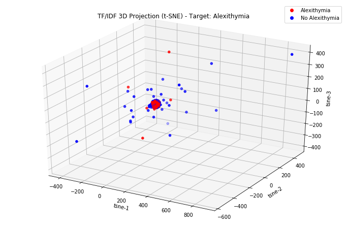

```python
colors = {1:'red', 0:'blue'}
ax = plt.figure(figsize=(12,8)).gca(projection='3d')
ax.scatter(
    xs=feats_df["tsne-1"],
    ys=feats_df["tsne-2"],
    zs=feats_df["tsne-3"],
    c=feats_df['Alex_A'].apply(lambda x: colors[x])
)
ax.set_xlabel('tsne-1')
ax.set_ylabel('tsne-2')
ax.set_zlabel('tsne-3')

legend_elements = [Line2D([0], [0], marker='o', color='w', label='Alex', markerfacecolor='r', markersize=8),
                   Line2D([0], [0], marker='o', color='w', label='NoAlex', markerfacecolor='b', markersize=8)]
ax.legend(legend_elements, ['Alexithymia','No Alexithymia'])

plt.title("TF/IDF 3D Projection (t-SNE) - Target: Alexithymia")
plt.show()
```

- Looks like TF/IDF vector space model (t-SNE-projected) is a not good candidate to classify alexithymia

### Does TF/IDF 3D-projected (t-SNE) features discriminate cards?

```python
# Get the cards df with t-sne variables from feats_df
# drop under-represented cards
cards_df = feats_df.drop(feats_df[(feats_df.Card != '9VH') & (feats_df.Card != '1') & (feats_df.Card != '11') & (feats_df.Card != '13HM')].index)
```

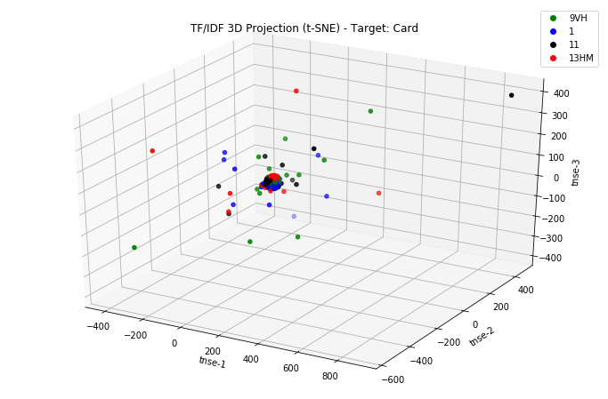

```python
colors = {'9VH': 'blue', '1': 'red', '11': 'green', '13HM': 'black'}
ax = plt.figure(figsize=(12,8)).gca(projection='3d')
ax.scatter(
    xs=cards_df["tsne-1"],
    ys=cards_df["tsne-2"],
    zs=cards_df["tsne-3"],
    c=cards_df['Card'].apply(lambda x: colors[x])
)
ax.set_xlabel('tnse-1')
ax.set_ylabel('tnse-2')
ax.set_zlabel('tnse-3')
legend_elements = [Line2D([0], [0], marker='o', color='w', label='9VH', markerfacecolor='green', markersize=8),
                   Line2D([0], [0], marker='o', color='w', label='1', markerfacecolor='blue', markersize=8),
                   Line2D([0], [0], marker='o', color='w', label='11', markerfacecolor='black', markersize=8),
                   Line2D([0], [0], marker='o', color='w', label='13HM', markerfacecolor='red', markersize=8)]
ax.legend(legend_elements, ['9VH','1','11','13HM'])
plt.title("TF/IDF 3D Projection (t-SNE) - Target: Card")
plt.show()
```

- Looks like TF/IDF vector space model (t-SNE-projected) is a not good candidate to classify cards either